# Univariate Stats_Week4

Author

Michael Cao

Published

February 5, 2025

**Exercise #1:**

Describing the center and spread for the variable *age*, drawn from the 2022 GSS.

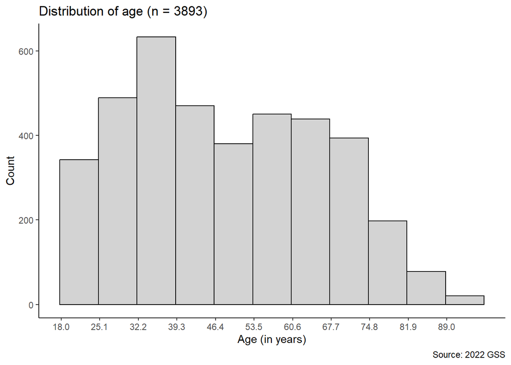

Mean ($\bar{x}_{age}$):

$\bar{x}_{age} = \frac{1}{n} \sum_{i=1}^{n} x_i$

$\bar{x}_{age} = 48.2445415$

Standard Deviation ($s_{age}$):

$s_{age} = \sqrt{\frac{1}{n-1} \sum_{i=1}^{n}(x_i-\bar{x}_{age})^2}$

$s_{age} = 17.7469306$

$\bar{x}_{age}$ measures the center of the *age* sample distribution, which here is balanced around 48.2 years old—so I’d say most of the sample tends to be middle-aged. $s_{age}$ tells us each observation (respondent’s age) in the sample deviates from the mean (48.2 years) by a typical distance of 17.7 years. This seems pretty high, which would suggest a good amount of variability in sample ages, including both younger and older ages.

Plotting the probability density distribution of *age*, and then approximating the normal distribution of *age*, given $\text{age} \sim N(48.2, 17.7)$:

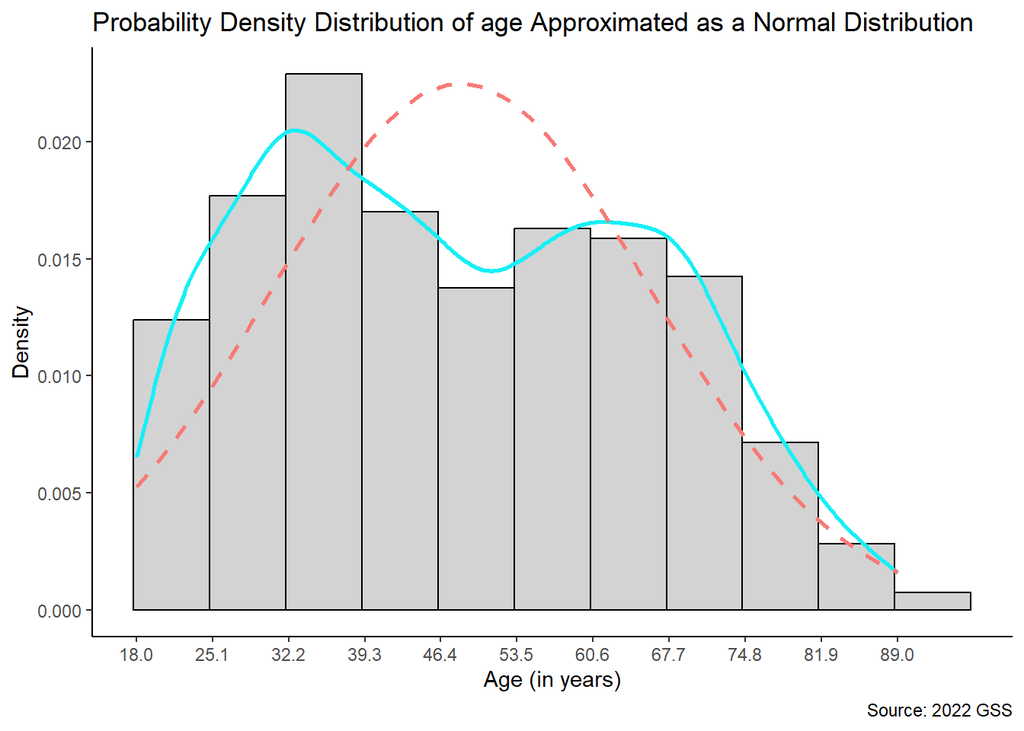

Comparing the normal approximation to the observed empirical distribution, we notice:

- The normal approximation is simultaneously under-approximating the frequency of tail-end younger ages and older ages, while over-approximating the frequency of middle ages in the sample.
- As a consequence of this, the normal approximation seems to miss the slight bimodality of the empirical sample distribution that has peaks towards young and older ages.
- The normal approximation also assumes the sample distribution stretches to non-existent ages lesser or greater, respectively, than the minimum and maximum values of the sample.

**Exercise #2:**

Describe the center and spread for the variable *hompop* (household size), drawn from the 2022 GSS. I use `geom_bar()` in my `ggplot()` argument because I treat *hompop* as discrete.

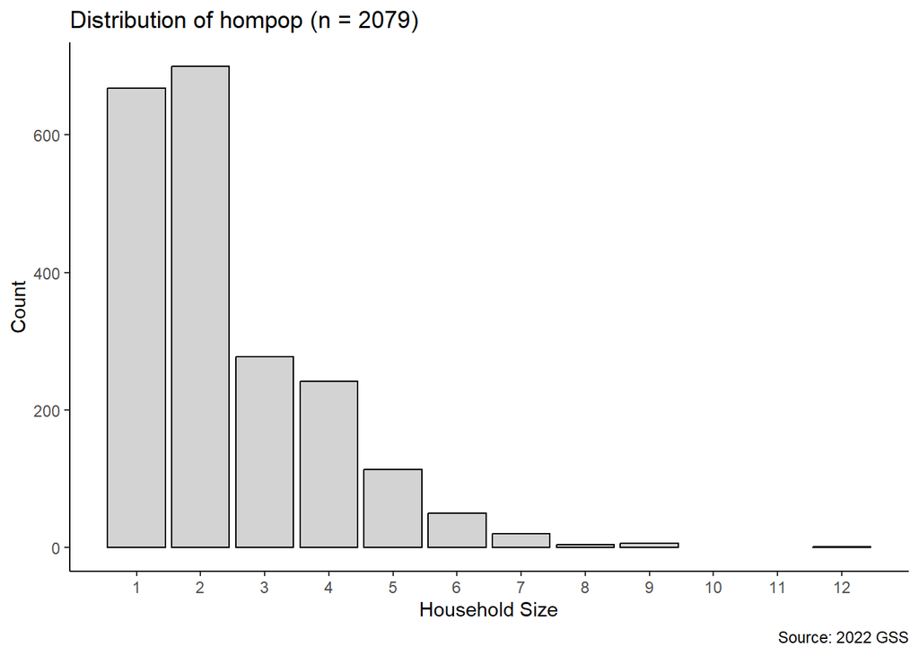

Mean ($\bar{x}_{homepop}$):

$\bar{x}_{homepop} = \frac{1}{n} \sum_{i=1}^{n} x_i$

$\bar{x}_{pop} = 2.3857624$

Standard Deviation ($s_{homepop}$):

$s_{homepop} = \sqrt{\frac{1}{n-1} \sum_{i=1}^{n}(x_i-\bar{x}_{homepop})^2}$

$s_{homepop} = 1.4615078$

Plotting the probability density distribution of *hompop*, and then approximating the normal distribution of *hompop*, given $\text{hompop} \sim N(2.4, 1.5)$:

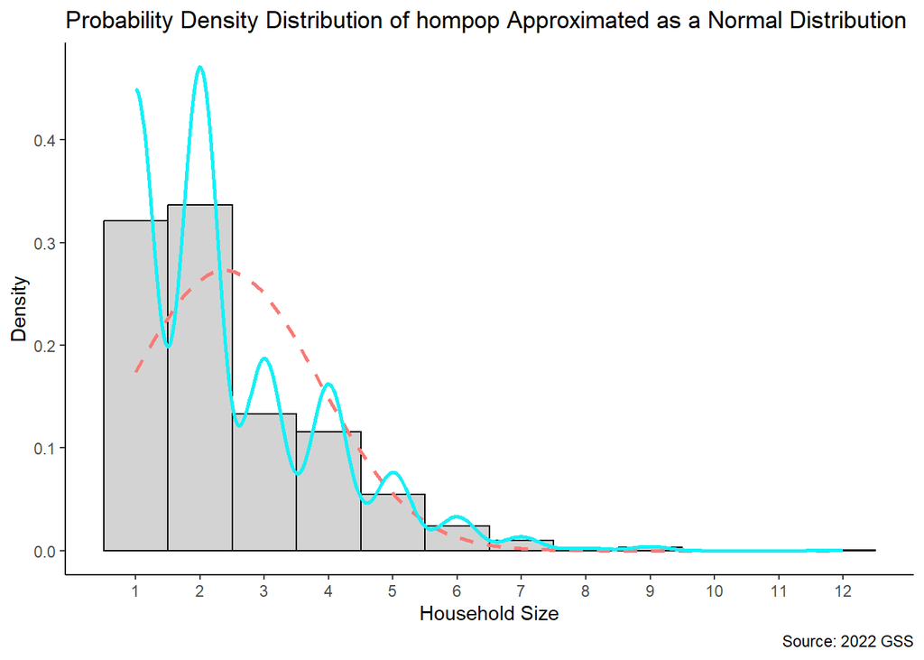

Comparing the normal approximation to the observed empirical distribution, we notice:

- Though both distributions are unimodal, the normal approximation appears to miss the right-skew of the sample distribution.
- Because the normal approximation assumes a symmetrical shape, a glaring issue is that it assumes negative household sizes, which is not possible. I suppose 12+ household sizes is theoretically possible, but extremely rare, which actually I think is captured by the normal approximation.
- The normal approximation is also under-approximating the frequency of smaller household sizes in the sample distribution.